# Bayesian Point Estimates and Credible Intervals

Jeff

2026-04-10

## Bayes-ball…

We’ll review our baseball example from lecture.

Suppose $X_1, \ldots, X_n$ represent a hit (1) or strikeout (0) during “at bats” by a made-up MLB rookie Jacob (count walks as a hit). We will assume independence for at bats, and we can consider each $X_i$ as a Bernoulli trial with probability of success $p$. We could therefore interpret $p$ as Jacob’s “true” batting average.

We know that $0 \leq p \leq 1$ where if $p=0$ then Jacob will never get a hit and if $p=1$ then Jacob will always gets a hit. Note that an “average” hitter tends to have a batting average around 0.25 for their career (1 in 4 at bats result in a hit), and a top tier hitter can end up around 0.33 (1 in 3 at bats).

We will walk through this thought experiment in both the Bayesian and frequentist paradigms while contrasting results.

## Strong priors

Under the Bayesian paradigm, we assume $p$ itself is a random variable. For this particular example, my write-up suggests that we have pretty solid information about what $p$ ‘should’ look like — this is an ideal scenario for the Bayesian approach.

To summarize, we know that $p$ is bounded by [0, 1] and is much, much more likely to fall somewhere in the lower third of that interval (but probably not in [0, .1] for an MLB player). I’ll suggest that $p \sim \text{Beta}(\alpha=30, \beta=100)$ is a sensible prior. This assumes, before Jacob ever steps up to the plate, that his true batting average is described by this probability density:

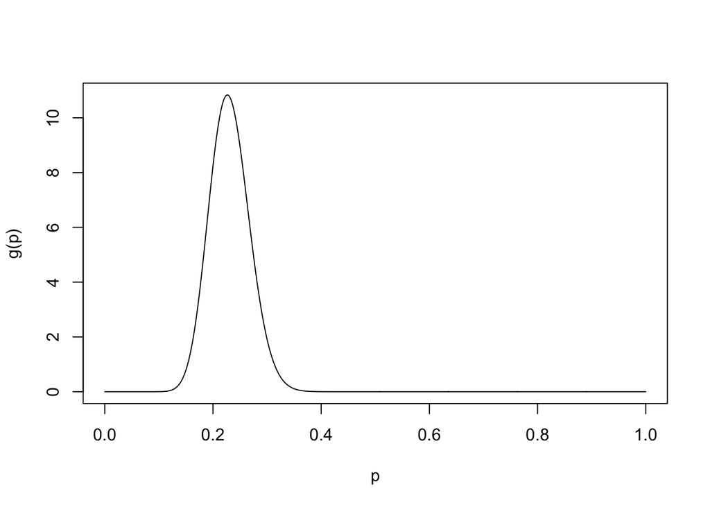

```r
curve(dbeta(x, 30, 100), n=1000, xlab="p", ylab="g(p)")
```

## Jacob’s first game

Jacob has 3 hits during 5 at bats in his first MLB game.

Majority of your statistics studies, you have likely followed the frequentist paradigm that $p$ is a fixed, but unknown, value. Our previous work suggests that
$$\hat{p}_f = \frac{\sum x_i}{n}$$
is a good estimator for this paradigm. So our frequentist point estimate for Jacob is
$$\hat{p}_f = 3/5 = 0.6$$

The Bayes mean estimator is
$$\hat{p}_b =
\frac{\sum x_i + \alpha}{n + \alpha + \beta}.$$
So our Bayesian point estimate for Jacob is
$$\hat{p}_b =
\frac{3+30}{5+30+100} = 0.244$$

Which approach is better?

It is easy to argue that the Bayesian approach is more likely to be closer to Jacob’s career batting average in the long run (since no player in history has come even close to batting at 0.6 for their career). The Bayesian estimator is therefore incorporating our prior belief that Jacob is extremely unlikely to reach that mark in the longrun.

Furthermore, we have only seen Jacob play one game! This is a small sample size to estimate from. The Bayesian estimator is therefore ‘forcing’ our estimate of Jacob’s batting average closer to that of an average player through our prior distribution on $p$.

## Jacob’s first season

So what if Jacob has a phenomenal first season? Let’s say 238 hits during 684 at bats. This would have made him the best in most recent seasons.

Frequentist:
$$\hat{p}_f = \frac{238}{684}
= 0.348$$

Bayesian:
$$\hat{p}_b =
\frac{238+30}{684+30+100} = 0.329$$

As you can see, while the prior distribution is still pulling Jacob’s mean estimate towards that of an average player, the larger sample of observed data is much more heavily influencing the estimate.

One can see as we move towards larger and larger sample sizes, the frequentist and Bayesian paradigms converge towards agreement on the point estimate.

## Uninformative priors

What if we pretend that we are ignorant about the general form of batting averages, aside from being bounded on [0,1]? Suppose we assume $p \sim \text{Beta}(\alpha=1, \beta=1)$, which is equivalent to a standard uniform:

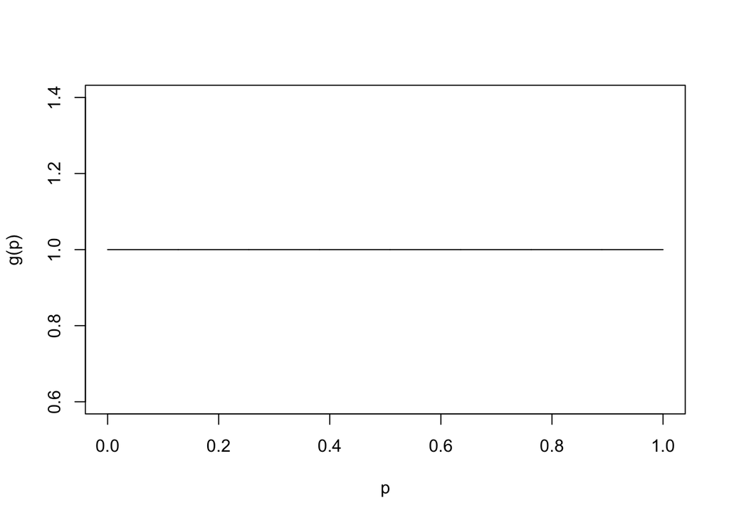

```r
curve(dbeta(x, 1, 1), n=1000, xlab="p", ylab="g(p)")
```

Let’s say Jacob goes 1 for 5 in his first game:

Frequentist:
$$\hat p_f = \frac{1}{5} =
0.2$$

Bayesian:
$$\hat p_b = \frac{1+1}{5+1+1} =
0.286$$

Which are fairly close even on a small sample size, though its worth noting that the uniform prior is pulling the Bayes estimator somewhat towards the expected value of that prior (in this case, the value 0.5). As discussed in class, if we focus on the posterior mode (rather than mean), then the frequentist and Bayesian paradigms agree on the point estimate.

(NOTE 1: While these are often called uninformative, or ignorant, priors, some statisticians argue against that wording, and even their usage. The crux of the argument is that a uniform prior distribution actually assumes quite a bit about your parameter. Namely, that each value of the parameter is equally likely.)

## Frequentist Confidence Intervals

At the beginning of lecture 4, we reviewed the framework for frequentist confidence intervals. The code for our animation on slide 4, which is for a (symmetric) 95% CI for $\mu$, follows:

```r
curve(dnorm(x), from=-4, to=4, lwd=3, xlab="", ylab="", xaxt="n", yaxt="n")
axis(1, at = c(0), labels = c(expression(mu)))
```

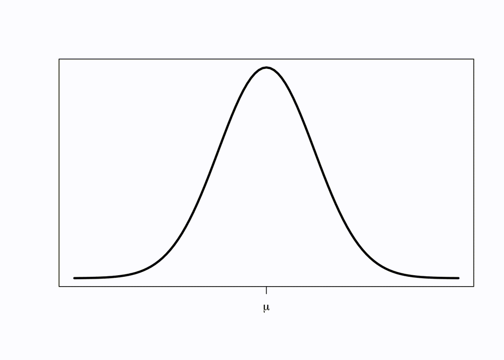

```r
set.seed(34156426)
xbar <- rnorm(1000)
cibound <- cbind(xbar-1.96, xbar+1.96)
contmu <- (cibound[,1]<0 & cibound[,2]>0)
for(i in c(1:99, seq(100, 1000, length.out=91))){
  curve(dnorm(x), from=-4, to=4, lwd=3, xlab="", ylab="", xaxt="n", yaxt="n", main=bquote(paste("Repetitions: ", .(i), "    ", "Contains ", mu, ": ", .(sum(contmu[1:i]) ))))
  axis(1, at = c(0), labels = c(expression(mu)))
  axis(1, at = c(xbar[i], cibound[i,1], cibound[i,2]), labels = c(expression(bar(x)), "(", ")"), col="red")
}
```

We then discussed the idea of lopsided confidence intervals. Some of you may have been exposed to one-sided confidence intervals, which tend to be the more practical use-case (`I don’t care at all if I underestimate $\mu$, but I would like 95% confident upper-bound for it’). But the gist of what I was trying to get across in lecture is that lopsided intervals are just as mathematically sound, and may make sense when our sampling distribution is non-symmetric, etc. Here is the code for the animation on slide 6:

```r
curve(dnorm(x), from=-4, to=4, lwd=3, xlab="", ylab="", xaxt="n", yaxt="n")
axis(1, at = c(0), labels = c(expression(mu)))
```

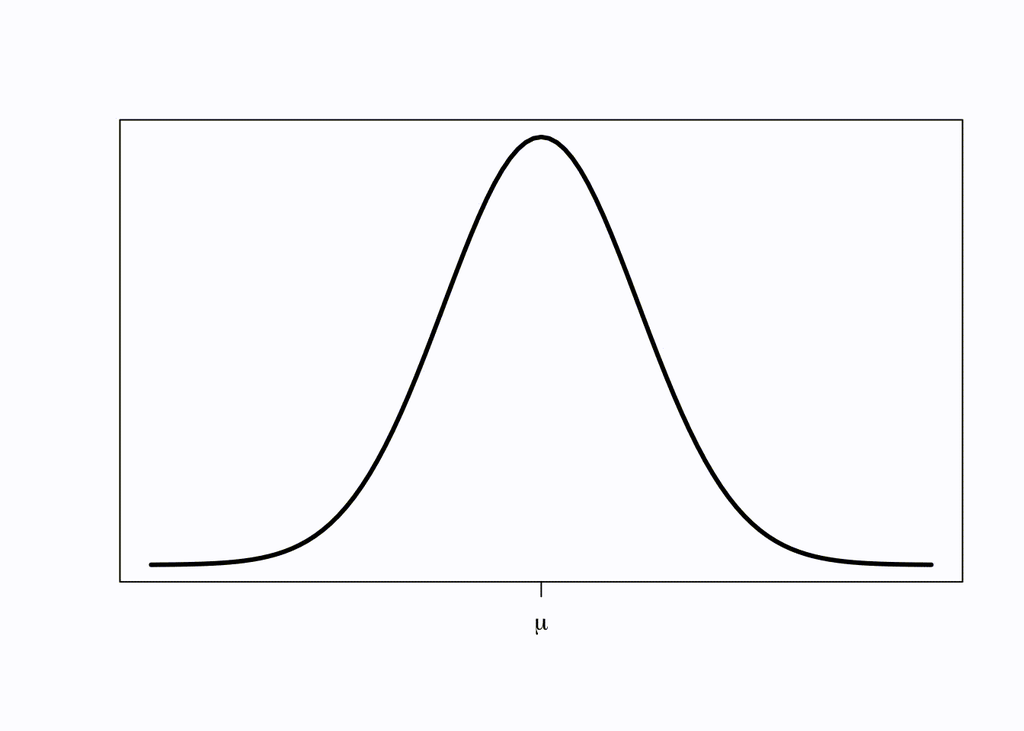

```r
set.seed(34156426)
xbar <- rnorm(1000)
cibound <- cbind(xbar-1.65, xbar+3)
contmu <- (cibound[,1]<0 & cibound[,2]>0)
for(i in c(1:99, seq(100, 1000, length.out=91))){
  curve(dnorm(x), from=-4, to=4, lwd=3, xlab="", ylab="", xaxt="n", yaxt="n", main=bquote(paste("Repetitions: ", .(i), "    ", "Contains ", mu, ": ", .(sum(contmu[1:i]) ))))
  axis(1, at = c(0), labels = c(expression(mu)))
  axis(1, at = c(xbar[i], cibound[i,1], cibound[i,2]), labels = c(expression(bar(x)), "(", ")"), col="red")
}
```

## Bayesian Credible Interval

We then returned to the Bayesian framework and our baseball example to show the ease at which we can find credible intervals using quantiles.

Jacob’s first game (3 hits during 5 at bats) results in the following credible interval

```r
curve(dbeta(x, 33, 102), col="red", ylab="", xlab="p", lwd=3, n=1000)
qbeta(0.025, 33, 102)
```

```
## [1] 0.1759813
```

```r
qbeta(0.975, 33, 102)
```

```
## [1] 0.3200767
```

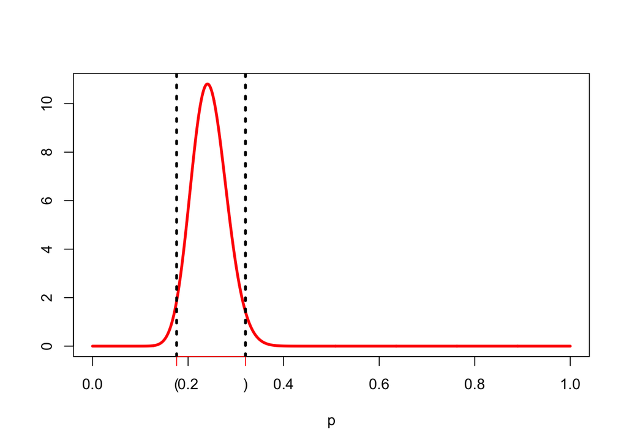

```r
axis(1, at=c(qbeta(0.025, 33, 102), qbeta(0.975, 33, 102)), labels=c("(", ")"), col="red")
abline(v=qbeta(0.025, 33, 102), lty="dotted", lwd=3)
abline(v=qbeta(0.975, 33, 102), lty="dotted", lwd=3)
```

which in the Bayesian framework allows us to interpret ``there is a 95% chance that Jacob’s true batting average falls somewhere between (0.176, 0.320).’’

In contrast, most frequentist approaches for this small sample size would end up with something along the lines of ``we are 95% confident that Jacob’s true batting average is somewhere between (0.2, 0.9).’’

For Jacob’s first season, our Bayesian framework provides

```r
curve(dbeta(x, 268, 546), col="red", ylab="", xlab="p", lwd=3, n=1000)
qbeta(0.025, 268, 546)
```

```
## [1] 0.2973826
```

```r
qbeta(0.975, 268, 546)
```

```
## [1] 0.3618888
```

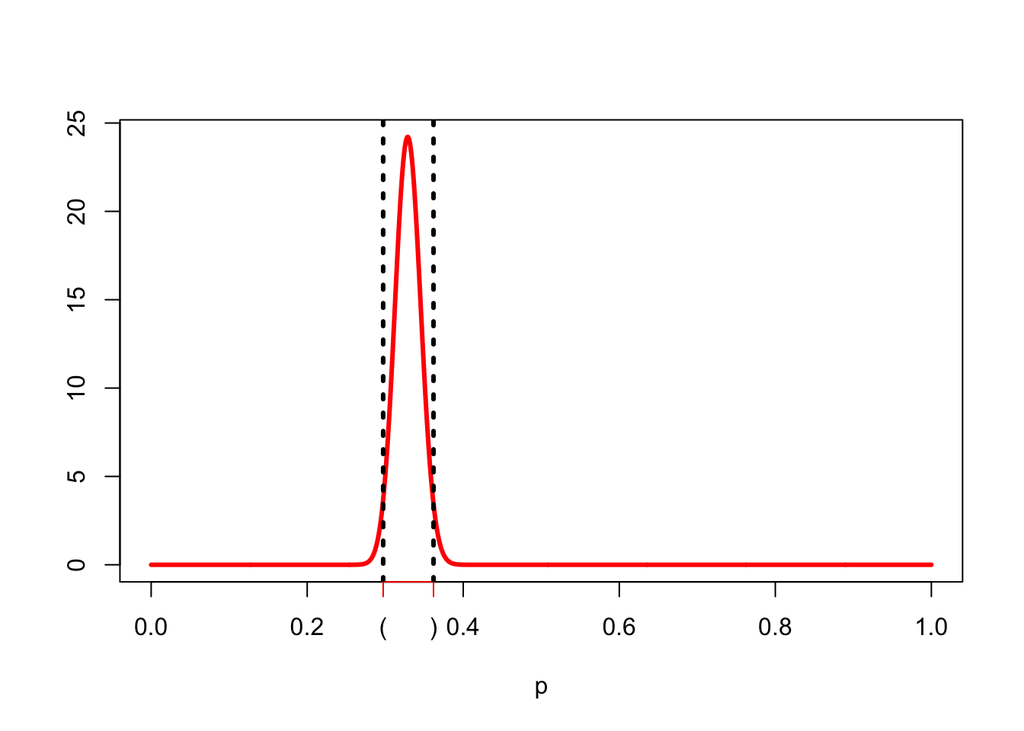

```r
axis(1, at=c(qbeta(0.025, 268, 546), qbeta(0.975, 268, 546)), labels=c("(", ")"), col="red")
abline(v=qbeta(0.025, 268, 546), lty="dotted", lwd=3)
abline(v=qbeta(0.975, 268, 546), lty="dotted", lwd=3)
```

and the interpretation ``There is a 95% chance that Jacob’s true batting average falls somewhere between (0.297, 0.362).’’

We then illustrated the perils of mistakes with a strong prior…

```r
curve(dbeta(x, 338, 476), col="red", ylab="", xlab="p", lwd=3, n=1000)
qbeta(0.025, 338, 476)
```

```
## [1] 0.3816095
```

```r
qbeta(0.975, 338, 476)
```

```
## [1] 0.4492519
```

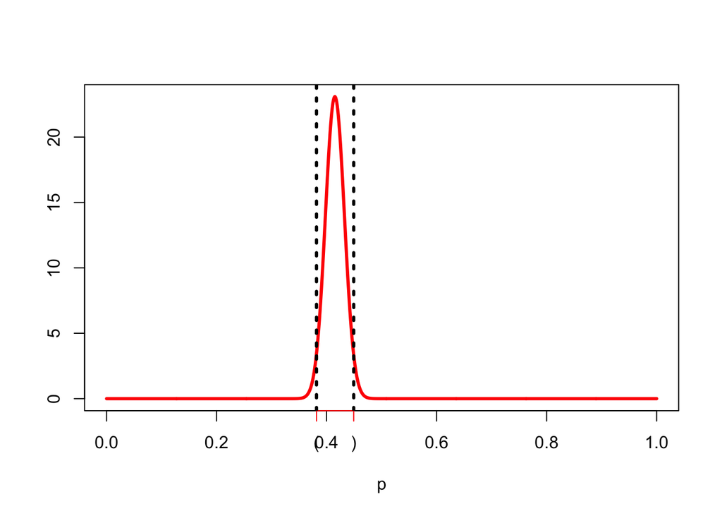

```r
axis(1, at=c(qbeta(0.025, 338, 476), qbeta(0.975, 338, 476)), labels=c("(", ")"), col="red")
abline(v=qbeta(0.025, 338, 476), lty="dotted", lwd=3)
abline(v=qbeta(0.975, 338, 476), lty="dotted", lwd=3)
```

which provided a credible interval that did not include the observed batting average despite a large sample size (n=684).